# MotoGP - exploring the corelation between age and performance of the MotoGP rider.

## 1. Introduction

I struggled a little to find the right data set for my project. I wanted to do somthing orginal and unique. For my final project for Introduction to Programming II I chose to do Data Visualization, so I alredy anlalized some data about Climate change, Pay gap between Male/female etc. as well as Life expectancy in different countries. (link [here](https://pavelosky.github.io/Data_visualizer/))

As I'm a big fan of MotoGP I was curious if I can find something interesting regarding this topic. Fortunately, there is a dataset available on kaggle.com - [MotoGP Race Results](https://www.kaggle.com/datasets/amalsalilan/motogpresultdataset?resource=download)

Through this project, I dived into the details of the dataset. I will try to find interesting patterns and trends within the data. My main goal is to examine the performance of famous riders, understand how age affects race outcomes, and explore the "Did Not Finish" incidents during different seasons. This dataset has a lot of interesting values, like rider's number, race time or even average race speed. Let me take you on to journey through the world of the data of the King's class of motorbike racing.

For the purpose of this project I try to put myself in a position of a Junior Data Scientist at Dorna (the company that organizes MotoGP) that was assigned a task of finding valuable and interesting data from a provided raw dataset, without any clear objective. The goal is to explore the data based on my knowlege of the topic, draw some conclusions from my findings and the data provided and set objectives as I go through the exploratory phase.

### 1.1 About Dataset

This dataset contains comprehensive results of MotoGP races from various years, categories and circuits. It includes information such as the year of the race, the category of the race, the circuit name, the rider and team information, the bike used, the rider's position, the points earned and the country of the rider. The dataset also includes other additional information like the speed, number and time of the rider. This dataset is suitable for anyone looking to analyze the results of MotoGP races and gain insights into the performance of riders, teams and circuits. The dataset contains 56396 rows and 15 columns and is in a pandas Dataframe format

- **year:** The year in which the race took place.
- **category:** The category of the race such as MotoGP, Moto2, Moto3 etc.
- **sequence:** The sequence of the race in the season.
- **shortname:** A short name of the circuit where the race took place.
- **circuit_name:** The name of the circuit where the race took place.
- **rider:** A unique identifier for the rider.
- **rider_name:** The name of the rider.
- **team_name:** The name of the team the rider was riding for.
- **bike_name:** The name of the bike used by the rider.
- **position:** The final position of the rider in the race.
- **points:** The number of points earned by the rider in the race.
- **number:** The number worn by the rider during the race.
- **country:** The country of the rider.
- **speed:** The average speed of the rider during the race.
- **time:** The time taken by the rider to complete the race

### 1.2 Ethical considerations

#### 1.2.1 - Scraping the data

MotoGP official website does not allow for using the data provided on their website unless it's specifically said so.

After taking a closer look on the [Terms of Use](https://www.motogp.com/en/Terms+of+Use), I've found that unfortunately points 1 and 3 state respectively *Any unauthorised use of the content of Dorna Channels will be prosecuted. Unless a specific Content is expressly authorised for downloading and it is so stated, the Content may not be downloaded. Consequently, any unauthorised download is a legal infringement with all its consequences.* and *You are only authorised to use Dorna Channels for personal purposes. You are therefore an end consumer and not a retailer or merchant. You are not permitted to provide, copy, exchange, modify, sell or transmit any Content that you access through the Dorna Channels for any purpose, whether for profit or free of charge.*.

For the most part I relied on the data available on Wikipedia. However, scraping the data from this popular source is very inacurate and requires a lot of cleaning.

#### 1.2.2 Onward use / reuseage of data and derived data

The utilization of the source data, requires compliance with the terms and conditions stipulated by each publication during that period. Additionally, obtaining separate permission for usage may be necessary. It is important to note that any data derived from the source, would be subject to the same restrictions as the source text itself.

The analysis and conclusions presented in this project are entirely my own and independent of the original sources.

## 2. Data exploration/cleaning and gathering additional information

```python
# necessary libraries and modules
import numpy as np
import pandas as pd
import csv
import requests
from bs4 import BeautifulSoup
import datetime
import matplotlib.pyplot as plt

df = pd.read_csv("MotoGP race results\motogpresultdataset.csv")
```

### 2.1 - Exploration

I first want to take a closer look at the data at hand to see if I can spot something unusual or worth further exploration.

```python
df.head(10)
```

```python
df.tail(10)
```

The dataset spans from 1949 up to 2021. It's clear to see that some data is missing at the head of the set compared to the tail of the set.

Let's start with getting some values that all bikers would be interested in - speed.

```python
df['speed'].mean()
```

```
150.67336227427572
```

```python
df['speed'].std()
```

```
12.002393469104547
```

```python
df['speed'].describe()
```

```
count    33171.000000
mean       150.673362
std         12.002393
min         14.300000
25%        144.400000
50%        151.000000
75%        157.800000
max        666.900000
Name: speed, dtype: float64
```

The max value in the speed column is unrealistic. While the current top speed record in MotoGP is by [Brad Binder - Tissot Sprint, Mugello 2023 - 366.1 km/h](https://www.motogp.com/en/news/2023/06/10/brad-binder-and-ktm-smash-motogp-top-speed-record/364051), the values shown in the table are the average speed value throughout the race.

Let's find out more about it.

```python
df.sort_values(by=['speed'], ascending=False).head(20)
```

So clearly the top value in the table above stands out from the others. As the dataset is pretty big I will replace it with the average value for this category.

I see this is a category 250cc and it was in 1993. I will get the average of the speed values in this category from the 90s, and replace it with this value.

```python
show_250 = df[(df['category'] == '250cc') & (df['year'].between(1990, 1999))]

df[(df['category'] == '250cc') & (df['year'].between(1990, 1999))]
```

```python
average_250 = show_250['speed'].mean()
print(average_250)
```

```
151.47408880053015
```

### 2.2 Cleaning

Let's now move on to replacing the value in the row 20326

```python
df.at[20326, 'speed'] = 151.5
```

```python
df['speed'].describe()
```

```
count    33171.000000
mean       150.657825
std         11.662897
min         14.300000
25%        144.400000
50%        151.000000
75%        157.800000
max        183.700000
Name: speed, dtype: float64
```

Let's check it one more time to make sure the value is corrected.

```python
df.sort_values(by=['speed'], ascending=False).head(20)
```

Let's now check other columns for deviations.

```python
df.describe(include='all')
```

### 2.3 Further exploration and gathering more data

So the average position is 9 and the standard deviation is 7, but the max value for this column is 40. Currently, there are around 23 riders in a race so this also seems a bit off. Also, the min value is -5, which I have a hard time wrapping my head around as one cannot finish the race in the -5th position. I will try to find out more about this.

```python
df.sort_values(by='position', ascending=False)
```

I wasn't able to find the detailed data about the top row in table above, as the official MotoGP site has limited info from old races on their website, however I confirmed the 2nd and 3rd entry. Link [here](https://www.motogp.com/en/gp-results/2006/VAL/125cc/RAC/Classification)

```python
df[(df['position'] >= -5) & (df['position'] <= 0)]
```

```python
df[(df['shortname'] == 'MAL') & (df['year'] == 2010) & (df['category'] == 'MotoGP') ]
```

What I was able to find on the official website is that all the riders that didn't finish the race have now negative value in the position column in the dataset. It seems also that the value depends on the reason for not finishing the race.

I will try to find out the meaning of all the negative values. It might be useful later on when looking for the correlation.

```python
df[df['position'] < 0].sort_values(by='position', ascending=False)
```

I see there are only five unique negative values that from -5 to -1. I will find random rows with all unique negative values and check on the official MotoGP website for the reason of DNF (did not finish).  
For this, I will have to do some manual work.

Because most recent data is well documented I will also try to find the most recent data in the table by sorting values by the year.

```python
df[(df['position'] == -1) & (df['category'] == 'Moto3') & (df['shortname'] == 'EMI')].sort_values(by='year', ascending=False).head(5)
```

In my first search the value at the top was from 'category' Moto3 and 'shortname' EMI. On the official website I found that there were 6 riders that were "Not Classified", hence the conditions in the search. It's now safe to assume that:

-1 is **Not Classified**

```python
df[df['position'] == -2].sort_values(by='year', ascending=False).head(5)
```

The process is the same for all negative values, therefore I'm not going to describe it every single time.

-2 is **Not started**

```python
df[df['position'] == -3].sort_values(by='year', ascending=False).head(5)
```

-3 is **Excluded**

```python
df[df['position'] == -4].sort_values(by='year', ascending=False).head(5)
```

-4 is **Not finished first lap**

```python
df[df['position'] == -5].sort_values(by='year', ascending=False).head(5)
```

-5 is **Disqualified**

I've decided to put them all together in a dictionary. It makes the most sense to use this structure as it can be easily returned just by calling it's key and that's what I have in the table.

```python
reasons_for_not_finishing = {-1:'Not Classified', -2:'Not started', -3:'Excluded', -4:'Not finished first lap', -5:'Disqualified'}
print(reasons_for_not_finishing)
```

```
{-1: 'Not Classified', -2: 'Not started', -3: 'Excluded', -4: 'Not finished first lap', -5: 'Disqualified'}
```

### 2.4 Web scraping and preperation

What I am also interested in is a correlation between the rider's age and his performance. Since Wikipedia's copyrights are open for anyone to use ([link here](https://en.m.wikipedia.org/wiki/Wikipedia:Copyrights)), I'll try to search Wikipedia for all the raiders and see if I'm able to scrape this data from this online encyclopedia.

Checkin the most popular rider at the moment of writing - Marc Marquez, I see that link consists of the Wikipedia domain followed by rider's

example: https://en.wikipedia.org/wiki/Marc_Marquez

First I need to change the name format to the one that will be acceptable for Wikipedia.

```python
all_riders = df['rider_name'].unique()
print(len(all_riders))
print(all_riders)
```

```python
formatted_names = []
for name in all_riders:
    last_name, first_name = name.split(', ')
    formatted_name = f"{first_name}_{last_name}"
    formatted_names.append(formatted_name)

print(formatted_names)
print(len(formatted_names))
```

Now I have the riders' names in the correct format.

Checking the [site](https://en.wikipedia.org/wiki/Marc_Marquez) I visited earlier, I see that birthday is stored under `<span class="bday">1993-02-17</span>`.

Since there is a special class dedicated to birthdays this should be a pretty easy task. I will store the birthdays in a dictionary where the rider's name is a key, and birthday is a value as it allows for quick access based on the name. If I need to use it in the future I can easily access it iterating over the names from the table.

Briefly looking through the file exported on the first iteration of the bthday_scraper() function, and checking some of the riders that I know, I see that for the majority of riders the birthdate is correct, however, I see that there is at least one incorrect value in the file, this is Jack Miller that was born on 18 January 1995, while the data scraped from the internet shows 1992-07-10.

While investigating the edge cases I found that there are more entries for the same name in Wikipedia. However, I noticed that in a link for a rider's page in Wikipedia where there is someone else with same name the string "_(motorcyclist)" is added at the end. I'll try to scrape the data again with the condition to first try to find the link with "(motorcyclist)" at the end.

Note: The code below is the final iteration, as it turned out that there were a lot of wrong values returned as there are more people with the same name and last name as some of the riders.

```python
## IMPORTANT NOTICE - This part scrapes the data from over 2500 separate Wikipedia pages. It took my computer almost 40 minutes to run.
## It's now commented out to avoid accidental running.


def bthday_scraper():

    birthday_dict2 = {}

    for name in formatted_names:
        url_with_motorcyclist = f"https://en.wikipedia.org/wiki/{name}_(motorcyclist)"
        response = requests.get(url_with_motorcyclist)
        soup = BeautifulSoup(response.text, 'html.parser')
        bday_element = soup.find('span', class_='bday')

        if bday_element:
            birthday = bday_element.text
        else:
            url = f"https://en.wikipedia.org/wiki/{name}"
            response = requests.get(url)
            soup = BeautifulSoup(response.text, 'html.parser')
            bday_element = soup.find('span', class_='bday')

            if bday_element:
                birthday = bday_element.text
            else:
                birthday_dict2[name] = np.nan

        birthday_dict2[name] = birthday
        birthday = np.nan

    birthday_dict2
```

I will save it as a .csv file. It might come in handy in a future exlporation.

```python
# Now export the second dictionary to the excel file.
def export_to_csv():
    filename = './MotoGP race results/birthday_data2.csv'

    with open(filename, 'w', newline='') as file:
        writer = csv.writer(file)
        writer.writerow(['Name', 'Birthday'])

        for name, birthday in birthday_dict2.items():
            writer.writerow([name, birthday])

    print("CSV file exported successfully.")
```

I'm actually interested in a year of birth. I will then use it to calculate the age of a rider in a chosen season.

I will also change the format of the name to match the format in the dataframe.

```python
filename = './MotoGP race results/birthday_data2.csv'

birthday_dict2 = {}

with open(filename, 'r') as file:
    reader = csv.reader(file)
    next(reader)  # Skip the header row

    for row in reader:
        name, birthday = row
        birthday_dict2[name] = birthday

print(birthday_dict2)
```

### 2.5 Transformig the data

```python
# Changing the format of the name, to match the dataframe.

birthyear_dict2 = {}

for name, date in birthday_dict2.items():
    first_name, last_name = name.split('_')
    formatted_name = f"{last_name.title()}, {first_name.title()}"

    if date != 'nan':
        date_obj = datetime.datetime.strptime(date, '%Y-%m-%d')
        year = date_obj.strftime('%Y')
    else:
        year = np.nan

    birthyear_dict2[formatted_name] = year

print(birthday_dict2)
print(birthyear_dict2)
```

Let's now add the age column to the dataframe for each seson. This column will show rider's age at the time of the race in a given row.

```python
ages = []
for index, row in df.iterrows():
    rider_name = row['rider_name']
    year = row['year']
    birth_year = birthyear_dict2.get(rider_name)
    if birth_year and not pd.isnull(birth_year):
        age = int(year) - int(birth_year)
        ages.append(age)
    else:
        ages.append(None)

df['age'] = ages
df
```

At the first iteration, I saw some extremes in the age of a rider, so I also add the year_of_birth column to the dataset so that I can easily verify the information in the 'age' column

```python
year_of_births = []
for index, row in df.iterrows():
    rider_name = row['rider_name']
    birth_year = birthyear_dict2.get(rider_name)
    if birth_year and not pd.isnull(birth_year):
        year_of_births.append(int(birth_year))
    else:
        year_of_births.append(None)

df['year_of_birth'] = year_of_births
df
```

### 2.6 Investigating and cleaning scraped data

```python
df['age'].describe()
```

```
count    35732.000000
mean        25.020318
std          8.997963
min        -30.000000
25%         20.000000
50%         24.000000
75%         28.000000
max        240.000000
Name: age, dtype: float64
```

```python
sorted_df = df.sort_values(by='age', ascending=False, na_position='first')
sorted_df.tail(20)
```

This looks much better than the first iteration of this function. The average age is 25 and STD is just 8 which is something expected in a motorsport.

There are a few more things to clean up. After visiting https://en.wikipedia.org/wiki/List_of_Grand_Prix_motorcycle_racing_rider_records I see that the oldest ever rider to win a race was 46 years old, and the youngest was 15 years old.

For this reaserch I will replace the values for the age outside of the 13 - 55 range with the NaN value

```python
df.loc[(df['age'] < 13) | (df['age'] > 55), ['age', 'year_of_birth']] = np.nan
df
```

```python
df['age'].describe()
```

```
count    34942.000000
mean        24.385153
std          5.370241
min         13.000000
25%         20.000000
50%         24.000000
75%         28.000000
max         55.000000
Name: age, dtype: float64
```

```python
age_sorted_df = df.sort_values(by='age', ascending=False, na_position='last')
age_sorted_df.head(20)
```

### 2.7 Gathering comparison data

While browsing through the website I came across this page with MotoGP Legends. I'll try to also scrape this data from the website. This time I'll store the names in a list. I should have all the data about those riders in the data I gathered until now, so all I'm looking for is creating a list of Legends so that I might later compare them with the rest.

After taking a closer look on the [Terms of Use](https://www.motogp.com/en/Terms+of+Use), I've found that unfortunately points 1 and 3 state respectively *Any unauthorised use of the content of Dorna Channels will be prosecuted. Unless a specific Content is expressly authorised for downloading and it is so stated, the Content may not be downloaded. Consequently, any unauthorised download is a legal infringement with all its consequences.* and *You are only authorised to use Dorna Channels for personal purposes. You are therefore an end consumer and not a retailer or merchant. You are not permitted to provide, copy, exchange, modify, sell or transmit any Content that you access through the Dorna Channels for any purpose, whether for profit or free of charge.*.

Luckly I found similar list on Wikipedia called **MotoGP Hall of Fame**.

```python
# Function to get the legends names from the web

def legends_list():
    url = "https://en.wikipedia.org/wiki/MotoGP_Hall_of_Fame"
    table_class = "vcard"

    response = requests.get(url)
    soup = BeautifulSoup(response.content, "html.parser")

    names = []
    rows = soup.find_all(class_=table_class)

    for row in rows[0:]:  # Skip the header row
        name_element = row.find("a")
        if name_element:
            name = name_element.get_text(strip=True)
            names.append(name.replace(" ", "_"))

    names
```

Again I'll export it to .csv file to use in the future.

```python
def legends_to_csv():
    filename = './MotoGP race results/MotoGP_Hall_of_fame.csv'

    with open(filename, 'w', newline='') as file:
        writer = csv.writer(file)
        writer.writerow(['Name'])

        for name in names:
            writer.writerow([name])

    print("CSV file exported successfully.")
```

Loading the previously gathered data into the list.

```python
hall_of_fame_file = 'MotoGP race results/MotoGP_Hall_of_fame.csv'

hall_of_fame_names_list = []

with open(hall_of_fame_file, 'r') as file:
    reader = csv.reader(file)
    next(reader)  # Skip the first row

    for row in reader:
        name = row[0]
        hall_of_fame_names_list.append(name)

hall_of_fame_names_list
```

```python
# Getting the previously gathered data to match the data in the data frame

formatted_hall_of_fame_names_list = []

for name in hall_of_fame_names_list:
    first_name, last_name = name.split('_')
    formatted_name = f"{last_name.title()}, {first_name.title()}"

    formatted_hall_of_fame_names_list.append(formatted_name)

formatted_hall_of_fame_names_list
```

### 2.8 Grouping the data

One more thing I want to do is to group the data by categories. For this, I will again use a dictionary where the key is represented by category and the value is a data frame with the data from the chosen category.

```python
category_dataframes = {}
for category, group in df.groupby('category'):
    category_dataframes[category] = group.copy()

category_dataframes.keys()
```

```
dict_keys(['125cc', '250cc', '350cc', '500cc', '50cc', '80cc', 'Moto2', 'Moto3', 'MotoE', 'MotoGP'])
```

```python
category_dataframes['250cc']
```

### End of Part 2

I looked through the data, clened one unrealistic entry, found some interesting insights and gathered additional data that I will use in a second part of this project, where I will deep dive into correlations and try to visualize my findings.

# Part 3 - Hypothesis & Data anylysis

During the first part of this project I explored the data provided. While doing so, few questions crossed my mind. I'll try to analize the data that I now have and prove or disprove my working hypotheses.

1. MotoGP Legends have high success rate at the begining of their career while for the most riders, success comes with their experience.
2. The older the rider is the more likely it is that he will finish the race. (less DNF's - negative positions in a data set).
3. There are more DNF's at the first half of the season, then at the second half of the season.

### 3.1 - MotoGP Legends have high success rate at the begining of their career while for the most riders, success comes with their experience.

I will start by showing the Legends performance.

Important thing to point out here is that the lower the value the beter it is, as the position 1 is much better then position 12.

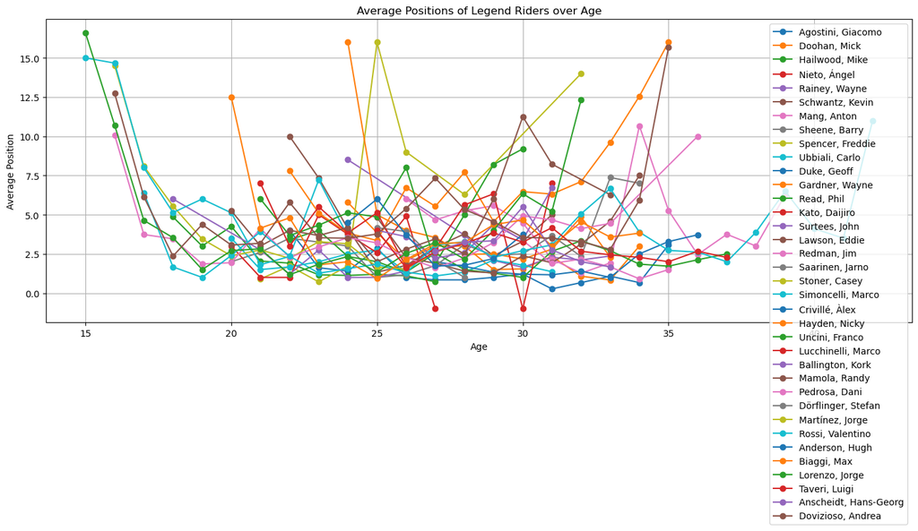

```python
legend_riders_df = df[df['rider_name'].isin(formatted_hall_of_fame_names_list)]

# grouping by age and rider_name and calculating the average position
legends_grouped_df = legend_riders_df.groupby(['age', 'rider_name'])['position'].mean().reset_index()


plt.figure(figsize=(17, 6))
for legend in formatted_hall_of_fame_names_list:
    legend_data = legends_grouped_df[legends_grouped_df['rider_name'] == legend]
    plt.plot(legend_data['age'], legend_data['position'], marker='o', label=legend)

plt.xlabel('Age')
plt.ylabel('Average Position')
plt.title('Average Positions of Legend Riders over Age')
plt.legend()
plt.grid(True)
plt.show()
```

The graph above is too messy and hard to read. I'll try to get the average of all riders and get it plotted on one line.

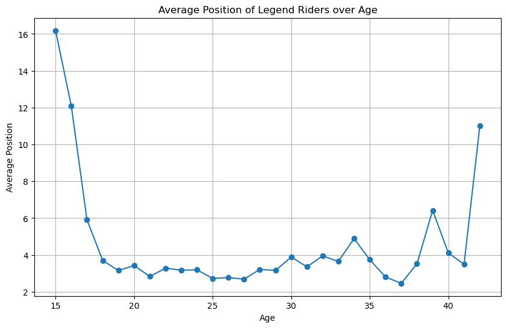

```python
legendsavg_grouped_df = legend_riders_df.groupby('age')['position'].mean().reset_index()

plt.figure(figsize=(10, 6))
plt.plot(legendsavg_grouped_df['age'], legendsavg_grouped_df['position'], marker='o')

plt.xlabel('Age')
plt.ylabel('Average Position')
plt.title('Average Position of Legend Riders over Age')
plt.grid(True)
plt.show()
```

It's now time to compare it with the performance of the non-legends in MotoGP

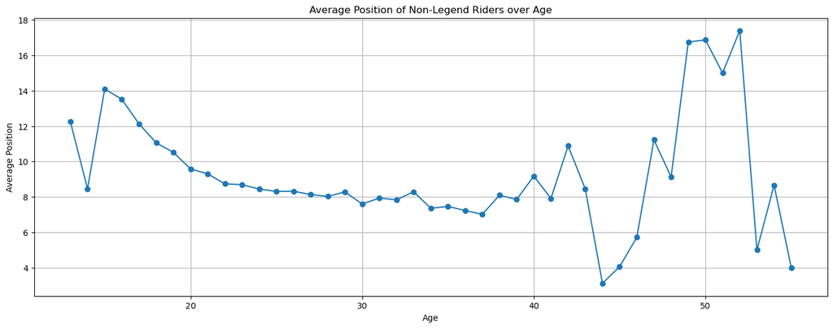

```python
# exclude legend riders
non_legend_riders_df = df[~df['rider_name'].isin(formatted_hall_of_fame_names_list)]

nonlegends_grouped_df = non_legend_riders_df.groupby('age')['position'].mean().reset_index()

plt.figure(figsize=(17, 6))
plt.plot(nonlegends_grouped_df['age'], nonlegends_grouped_df['position'], marker='o')

plt.xlabel('Age')
plt.ylabel('Average Position')
plt.title('Average Position of Non-Legend Riders over Age')
plt.grid(True)
plt.show()
```

And both graphs above represented in one.

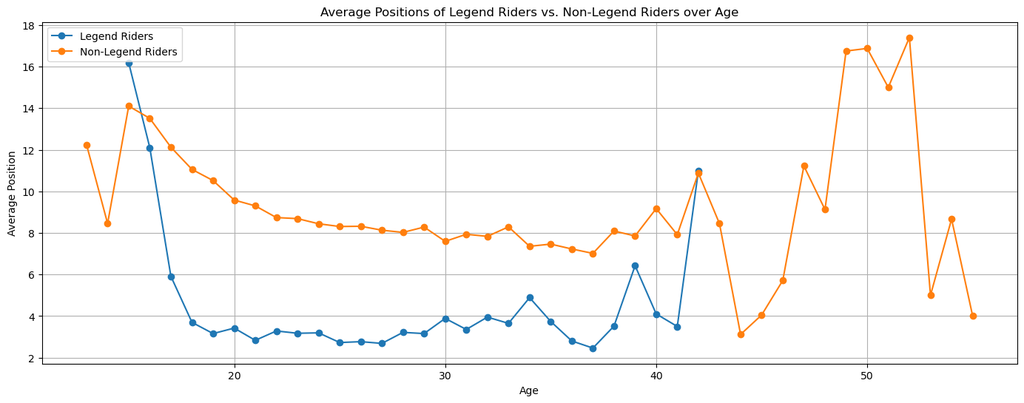

```python
plt.figure(figsize=(17, 6))
plt.plot(legendsavg_grouped_df['age'], legendsavg_grouped_df['position'], marker='o', label='Legend Riders')
plt.plot(nonlegends_grouped_df['age'], nonlegends_grouped_df['position'], marker='o', label='Non-Legend Riders')

plt.xlabel('Age')
plt.ylabel('Average Position')
plt.title('Average Positions of Legend Riders vs. Non-Legend Riders over Age')
plt.legend()
plt.grid(True)
plt.show()
```

### 3.1 Conclusion:

The values approaching 40 in the Age axis look like anomalies. This needs further investigation

### 3.2 - The older the rider is the more likely it is that he will finish the race. (less DNF's - negative positions in a data set).

For better visualization, I will represent my findings by the percentage of the finished races in predefined age groups.

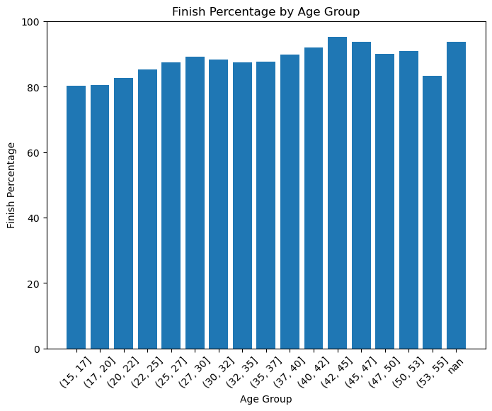

```python
age_intervals = [15,17,20,22,25,27,30,32,35,37,40,42,45,47,50,53,55]

# new column for age groups in the DataFrame
df['age_group'] = pd.cut(df['age'], bins=age_intervals).astype(str)

# the percentage of riders finishing the race for each age group
finish_percentage = df[df['position'] > 0].groupby('age_group')['rider_name'].count() / df.groupby('age_group')['rider_name'].count() * 100


plt.figure(figsize=(8, 6))
plt.bar(finish_percentage.index, finish_percentage.values)

plt.xlabel('Age Group')
plt.ylabel('Finish Percentage')
plt.title('Finish Percentage by Age Group')
plt.xticks(rotation=45)
plt.grid(False)
plt.show()
```

### 3.3 - There are more DNF's at the first half of the season, then at the second half of the season.

This is the most challenging to present as there is a lot of factors and calculations that need to be performed in order to acuratly represent this data.

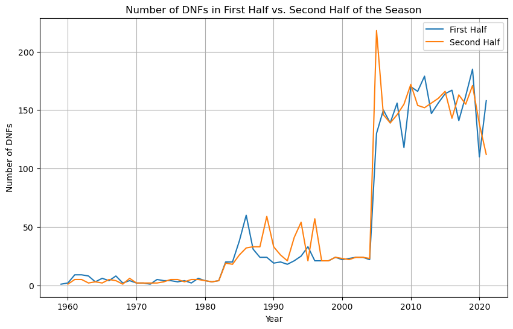

```python
dnf_df = df[df['position'] < 0]

# group by year and sequence, count the number of DNFs in each group
dnf_counts = dnf_df.groupby(['year', 'sequence']).size().reset_index(name='dnf_count')

# number of races in each year
total_races = df.groupby('year')['sequence'].max()

# half point for each year
half_point = total_races // 2

# aligning the indexes of dnf_counts and half_point
dnf_counts.set_index(['year', 'sequence'], inplace=True)
half_point = half_point.reindex(dnf_counts.index, level='year')

# Split into the first half and second half of the season
first_half_dnf = dnf_counts[dnf_counts.index.get_level_values('sequence') <= half_point].groupby('year')['dnf_count'].sum()
second_half_dnf = dnf_counts[dnf_counts.index.get_level_values('sequence') > half_point].groupby('year')['dnf_count'].sum()

# line graph with two separate lines for first half and second half
plt.figure(figsize=(10, 6))
plt.plot(first_half_dnf.index, first_half_dnf.values, label='First Half')
plt.plot(second_half_dnf.index, second_half_dnf.values, label='Second Half')

plt.xlabel('Year')
plt.ylabel('Number of DNFs')
plt.title('Number of DNFs in First Half vs. Second Half of the Season')
plt.legend()
plt.grid(True)
plt.show()
```

I'll also try to present it in a bar graph

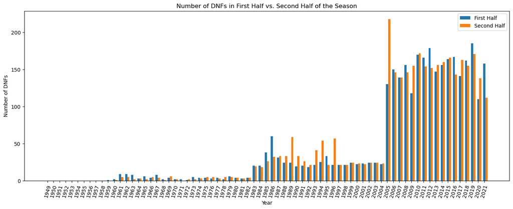

```python
years = total_races.index.unique()

# set the width of the bars
bar_width = 0.35

# index for first_half_dnf and second_half_dnf
new_index = pd.Index(years, name='year')

# first_half_dnf and second_half_dnf with the new index
first_half_dnf = first_half_dnf.reindex(new_index, fill_value=0)
second_half_dnf = second_half_dnf.reindex(new_index, fill_value=0)

x = np.arange(len(years))

# bar graph with separate bars for first half and second half
plt.figure(figsize=(17, 6))
plt.bar(x, first_half_dnf, width=bar_width, label='First Half')
plt.bar(x + bar_width, second_half_dnf, width=bar_width, label='Second Half')

plt.xlabel('Year')
plt.ylabel('Number of DNFs')
plt.title('Number of DNFs in First Half vs. Second Half of the Season')
plt.xticks(x, years)
plt.legend()
plt.grid(False)
plt.xticks(rotation=75)
plt.show()
```

### 3.3 Conclusion:

The graph above shows that there isn't a big difference in a DNFs when the race sequence is taken into account. For the big jump in 2005 I assume that there was some change in recording the DNFs.